# ImpfRisiko vs. CovidRisiko

Thomas.Strehl@at.ibm.com

4/11/2021

# ImpfRisiko vs. CovidRisiko

Die vorliegende Untersuchung versucht das Risiko einer Impfung und die Risiken, die mit einer Erkrankung an COVID-19 verbunden sind miteinander zu vergleichen. Im Vordergrund der Betrachtung steht die Wahrscheinlichkeit eines schweren oder tödlichen Verlaufes einer COVID-19 Erkrankung und die Wahrscheinlichkeit von schweren Nebenwirkungen oder Todesfällen als Nebenwirkung einer Impfung. Es werden folgende Informationen zusammengestellt:

- Die Wahrscheinlichkeit an COVID-19 schwer zu erkranken (Spitalsaufenthalt) oder zu sterben
- Die Wahrscheinlichkeit aufgrund der Impfung schwere Nebenwirkungen zu bekommen oder zu sterben

Beide Größen korrelieren sehr stark mit dem Alter, aber auch dem Geschlecht Zu berücksichtigen sind also u.a.:

- Alter und Geschlecht
- Eventuelle Vorerkrankungen
- Der Impfstoff
- Die vorherrschenden Mutanten im Untersuchungszeitraum und Gebiet
- Die Anzahl der asypmtomatischen Erkrankungen
- Die Schwere bei Erkrankung bei COVID-19 bzw. die Schwere der Nebenwirkungen bei Impfung
- Die Todesursache, deren zeitlicher Zusammenhang zur Impfung, und die Häufigkeit einer Todesursache ohne Impfung
- Die Verfügbarkeit von Daten

Informationen zu bleibenden Schäden sind weder für die Covid-19 Krankheit selbst noch für die Nebenwirkung der Impfung einfach zugänglich und werden hier nicht betrachtet.

## Demographische Daten Österreich

Im folgenden wird die Anzahl der Nebenwirkungen, Todesfälle und anderer Ereignisse auf die Anzahl pro 100.000 Einwohner bzw Geimpfte umgerechnet. Damit wird der direkte Vergleich von unterschiedlichen Berichten zu Impfnebenwirkungen sowie den im COVID-19 Umfeld üblichen Zahlen wie TagesInzidenz pro 100.000 Einwohner ermöglicht.

Eine entscheidende Rolle bei der Beurteilung der Wirkung, Nebenwirkungen und des Risikos einer Impfung spielen das Alter und das Geschlecht. Deshalb wird zunächst die Altersstruktur und die von Covid-19 unabhängige Sterblichkeit in Österreich dargestellt. Die demographischen Daten dazu werden u.a. von der Statistik Austria veröffentlicht.

https://portal.statistik.at/statistik.at/ext/statcube/jsf/dataCatalogueExplorer.xhtml

### Einwohner nach Altersgruppe und Geschlecht in Österreich

Zunächst die Alterstruktur in Österreich für 2019 in 20 fünf Jahres Intervallen. Die Einteilung in die beiden Klassen ‘Adult’ und ‘Retired’ wird später bei der Betrachtung der Impfnebenwirkungen verwendet werden.

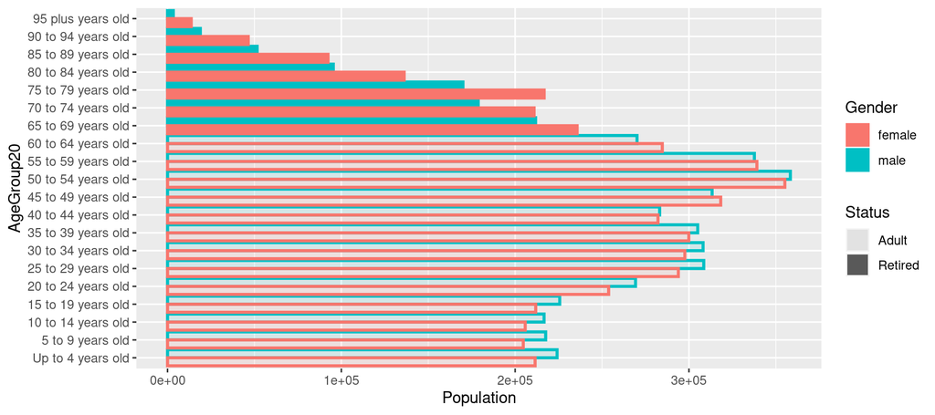

### Todesfälle nach Altersgruppe und Geschlecht in Österreich 2015-2019

Für die Todesfälle werden die Jahre 2015 bis 2019 betrachtet. Die Altersabhängigkeit ist in diesen Jahren sehr ähnlich. Auffällig die Abweichungen bei den Männern um die Altersgruppe 80-85. Das könnte mit dem Zweiten Weltkrieg zu tun haben.

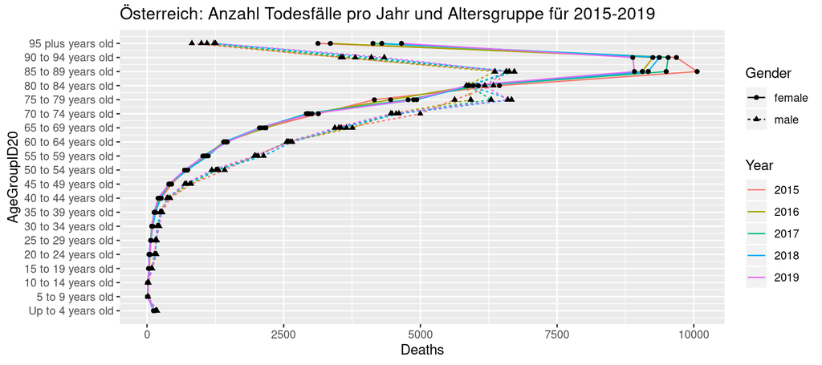

### Umrechnung auf Todesfälle pro 100000 Einwohner und Altersgruppe für 2019

Die Wahrscheinlichkeit in einem Jahr zu sterben steigt exponentiell mit dem Alter an. Sie ist mit 60-65 Jahren etwa zehn mal, und mit 80-85 Jahren etwa hundert mal so hoch wie mit 40-45 Jahren.

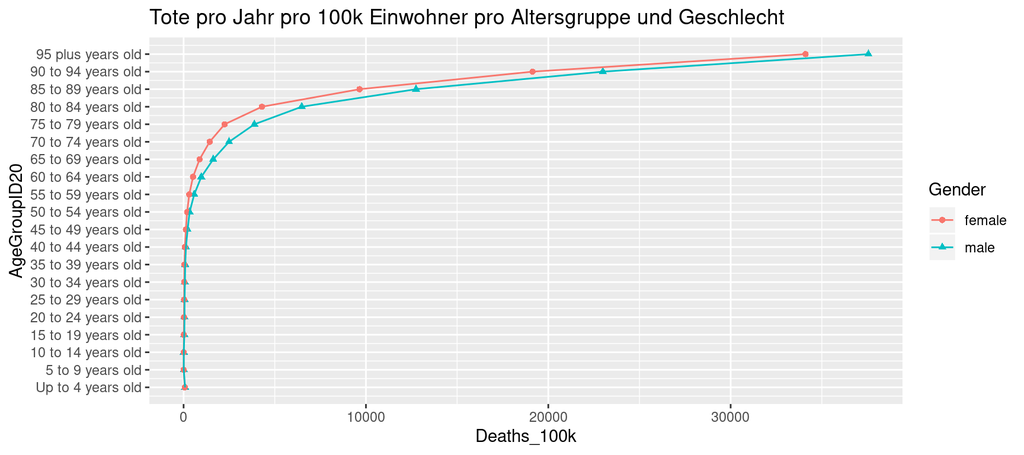

In der folgenden Tabelle sind die Alterstufen in die in den AGES COVID-19 Daten benutzten Intervalle zusammengefasst.

| AgeGroup15 | Gender | Population | Deaths | Deaths_100k |
| --- | --- | --- | --- | --- |
| Age_0_to_5 | female | 211489 | 135 | 64 |
| Age_0_to_5 | male | 224141 | 180 | 80 |
| Age_5_to_15 | female | 410482 | 28 | 7 |
| Age_5_to_15 | male | 434216 | 44 | 10 |
| Age_15_to_25 | female | 465638 | 78 | 17 |
| Age_15_to_25 | male | 494925 | 223 | 45 |
| Age_25_to_35 | female | 591537 | 170 | 29 |
| Age_25_to_35 | male | 616660 | 392 | 64 |
| Age_35_to_45 | female | 582112 | 332 | 57 |
| Age_35_to_45 | male | 588197 | 632 | 107 |
| Age_45_to_55 | female | 673458 | 1088 | 162 |
| Age_45_to_55 | male | 671691 | 1874 | 279 |
| Age_55_to_65 | female | 623776 | 2522 | 404 |
| Age_55_to_65 | male | 607792 | 4593 | 756 |
| Age_65_to_75 | female | 446565 | 5082 | 1138 |
| Age_65_to_75 | male | 390518 | 7893 | 2021 |
| Age_75_to_85 | female | 352851 | 10725 | 3040 |
| Age_75_to_85 | male | 265367 | 12776 | 4814 |
| Age_85_to_ | female | 152438 | 22452 | 14729 |
| Age_85_to_ | male | 73784 | 12167 | 16490 |

Zur Verdeutlichung des exponentiellen Charakters der Wahrscheinlichkeit mit zunehmendem Alter zu sterben eine logarithmische Darstellung.

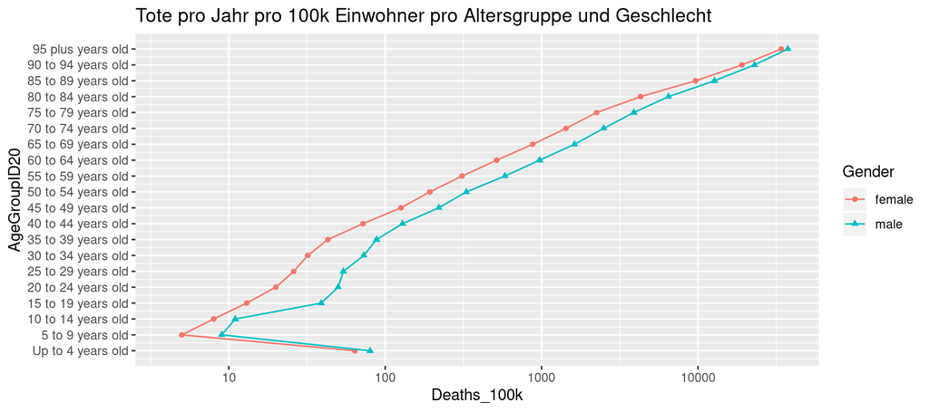

# Abschätzung des Risikos schwer an Covid-19 zu erkranken

Das Risiko an Covid-19 zu erkranken ist in erheblichem Ausmass von der Zahl der sozialen Kontakte, der Einhaltung der Abstandsregeln, den Hygiene Standards, der TagesInzidenz u.a.m. abhängig, ebenso wie vom Erreichungsgrad der Herdenimmunität. Das Ziel der Impfkampagne ist in jedem Fall die Wiederherstellung des Normalzustandes. Ohne Massnahmen würde die gesamte Bevölkerung in kurzer Zeit an COVID-19 erkranken, obgleich viele Verläufe asymtomatisch verlaufen würden.

Für die folgenden Betrachtungen wird davon ausgegangen, dass im ‘Normalbetrieb’ jeder/jede an COVID-19 erkranken würde. Es geht daher um die Betrachtung der schweren (Spitalsaufenthalt), schwersten (Intensivstation) und tödlichen Verläufe.

## Beispiel Wien

Als konkretes Fallbeispiel werden die COVID-19 Infektionen in Wien herangezogen, wie von AGES auf der ‘Open Data Platform’ veröffentlicht. Die Daten zu Altersgruppen und Bundesländern werden jeden Tag kummuliert seit 26.2.2020 zusammengestellt. Aktuell umfasst das einen Zeitraum von etwa einem Jahr.

### COVID-19 Erkrankungen seit Beginn der Pandemie (Q2/2020 bis Q1/2021)

Im Verlauf dieses Jahres haben sich massgebliche Faktoren geändert, darunter die COVID-19 Behandlungsmethoden in den Spitälern, das Auftreten von Mutationen sowie die Impfung der älteren, besonders gefährdeten Personen. Insofern ist die Betrachtung des Gesamtzeitraumes nur ein Mittelwert über unterschiedliche Phasen der Pandemie.

Hinweise zu den nachfolgenden Tabellen und Graphiken:

- Entsprechend der Vorgangsweise für die allgemeine Sterblichkeit pro Altersgruppe (siehe weiter oben) werden die absoluten Zahlen der Erkrankungen auf die Anzahl pro 100.000 Einwohner umgerechnet (Spalten Postfix ‘100k’)
- Zusätzlich wird der Anteil der Infizierten (Kürzel ‘Posit’) und Verstorbenen (Kürzel ‘Verst’) entlang der Altersgruppe aufsummiert (Spalten Prefix ‘cs’ = cumsum) und die Prozentsätze errechnet (Spalten PostFix ‘Proz’)

Zusammenfassung (stark gerundet)

- Bisher wurden 120.000 Menschen positiv getestet, 60.000 Männer und 60.000 Frauen
- Von den 60.000 Männern bzw. Frauen waren 90% der Männer und 85% der Frauen unter 65 Jahre alt
- Bisher verstarben an COVID-19 2000 Menschen, 1000 Männer und 1000 Frauen
- Von den 1000 verstorbenen Männern bzw. Frauen waren 100 = 10% der Männer und 6% = 60 der Frauen unter 65 Jahre alt

Diese Werte gelten für die Altersstruktur in Wien. Würde sich das Alter der Bevölkerung gleichmässig auf die Altersgruppen aufteilen, dann wäre der Anteil an verstorbenen Männer unter 65 Jahre 2.3%, der der Frauen 1.8%.

| AgeGroup | Gender | Posit | Posit100k | csPosit | csPosit100k | csPositProz | Verst | Verst100k | csVerst | csVerst100k | csVerstProz |
| --- | --- | --- | --- | --- | --- | --- | --- | --- | --- | --- | --- |
| <5 | M | 972 | 1910 | 972 | 1910 | 1.7 | 0 | 0.0 | 0 | 0.0 | 0.0 |
| 5-14 | M | 5242 | 5652 | 6214 | 7562 | 10.7 | 1 | 1.1 | 1 | 1.1 | 0.1 |
| 15-24 | M | 9187 | 8314 | 15401 | 15876 | 26.6 | 4 | 3.6 | 5 | 4.7 | 0.5 |
| 25-34 | M | 11362 | 7078 | 26763 | 22954 | 46.2 | 4 | 2.5 | 9 | 7.2 | 1.0 |
| 35-44 | M | 9336 | 6722 | 36099 | 29676 | 62.3 | 2 | 1.4 | 11 | 8.6 | 1.2 |
| 45-54 | M | 8987 | 6704 | 45086 | 36380 | 77.8 | 19 | 14.2 | 30 | 22.8 | 3.2 |
| 55-64 | M | 6707 | 5914 | 51793 | 42294 | 89.4 | 68 | 60.0 | 98 | 82.8 | 10.4 |
| 65-74 | M | 3001 | 4253 | 54794 | 46547 | 94.6 | 183 | 259.4 | 281 | 342.2 | 29.7 |
| 75-84 | M | 2198 | 4499 | 56992 | 51046 | 98.4 | 373 | 763.4 | 654 | 1105.6 | 69.2 |
| >84 | M | 934 | 7886 | 57926 | 58932 | 100.0 | 291 | 2456.9 | 945 | 3562.5 | 100.0 |
| <5 | W | 914 | 1896 | 914 | 1896 | 1.5 | 0 | 0.0 | 0 | 0.0 | 0.0 |
| 5-14 | W | 4620 | 5337 | 5534 | 7233 | 9.3 | 0 | 0.0 | 0 | 0.0 | 0.0 |
| 15-24 | W | 8950 | 8188 | 14484 | 15421 | 24.4 | 0 | 0.0 | 0 | 0.0 | 0.0 |
| 25-34 | W | 11172 | 7083 | 25656 | 22504 | 43.2 | 2 | 1.3 | 2 | 1.3 | 0.2 |
| 35-44 | W | 9603 | 7004 | 35259 | 29508 | 59.3 | 3 | 2.2 | 5 | 3.5 | 0.5 |
| 45-54 | W | 9416 | 6870 | 44675 | 36378 | 75.2 | 15 | 10.9 | 20 | 14.4 | 2.0 |
| 55-64 | W | 5937 | 5002 | 50612 | 41380 | 85.2 | 39 | 32.9 | 59 | 47.3 | 5.9 |
| 65-74 | W | 3067 | 3496 | 53679 | 44876 | 90.3 | 103 | 117.4 | 162 | 164.7 | 16.3 |
| 75-84 | W | 3043 | 4392 | 56722 | 49268 | 95.4 | 271 | 391.1 | 433 | 555.8 | 43.6 |
| >84 | W | 2711 | 9960 | 59433 | 59228 | 100.0 | 559 | 2053.8 | 992 | 2609.6 | 100.0 |

Um den Gesamtanteil der Menschen zu bestimmen, die sich im bisherigen Verlauf der Pandemie bereits mit COVID-19 infiziert haben, wird der Anteil der Asymptomatischen Infektionen benötigt. Eine Abschätzung dazu wird weiter unten auf Basis einer Prevalenz Studie der Statistik Austria im November 2020 versucht.

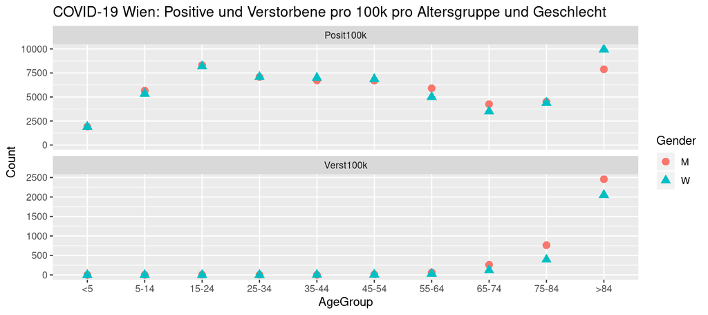

Die Anzahl der Verstorbenen pro 100.000 positiv Getestete nimmt mit dem Alter exponentiell zu. Das wird mit der im Stufenmodell für die TagesInzidenz vorgestellten y-Achse mit Verdoppelungsschritten deutlich.

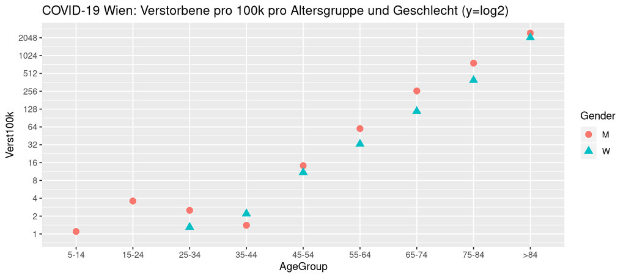

### Zusammenfassung auf zwei Altersgruppen

Die Daten zu den Nebenwirkungen der COVID-19 Impfungen nennen zumeist nur zwei Altersgruppen (Jung <-> Alt, Trennung 60-65 Jahre) und das Geschlecht. Für die folgenden Betrachtungen werden die AGES Daten zur Altersverteilung ebenfalls in die zwei Gruppen jünger/älter als 65 Jahre geteilt.

| AgeGroup | Gender | Posit | Verst | Posit_ | Verst_ | Posit100k | Verst100k | Posit100k_ | Verst100k_ |
| --- | --- | --- | --- | --- | --- | --- | --- | --- | --- |
| Retired | M | 6133 | 847 | 10.6 | 89.6 | 4672 | 645.3 | 41.9 | 98.1 |
| Retired | W | 8821 | 933 | 14.8 | 94.1 | 4788 | 506.4 | 42.9 | 98.6 |
| Working | M | 51793 | 98 | 89.4 | 10.4 | 6466 | 12.2 | 58.1 | 1.9 |
| Working | W | 50612 | 59 | 85.2 | 5.9 | 6369 | 7.4 | 57.1 | 1.4 |

### Abschätzung der Infektionen mit Todesfolge pro 100.000 Infektionen

Um diese Zahlen mit den letalen Nebenwirkungen einer COVID-19 Impfung pro 100.000 Menschen vergleichen zu können, muss von den ‘positiv gestesteten’ auf die ‘infizierten’ hochgerechnet werden, also die ‘asymptomatischen’ mitbetrachtet werden. Nimmt man an (bob), dass die Anzahl der Asymptomatischen zwischen 2 und 5 mal so hoch ist wir die der positiv getesteten, dann ergeben sich zwischen 2 und 5 Todesfälle pro 100.000 bei den Werktätigen, und zwischen 100 und 250 Todesfälle pro 100.000 bei den Pensionisten.

# Prevalenz von COVID-19 mit Abschätzung der Dunkelziffer

## StatistikAustria: PrevalenzStudie 11/2020

Studie vor dem 2ten Lockdown, am Höhepunkt der ‘2ten Welle’

- http://www.statistik.at/web_de/statistiken/menschen_und_gesellschaft/gesundheit/covid19/index.html
- http://www.statistik.at/wcm/idc/idcplg?IdcService=GET_PDF_FILE&RevisionSelectionMethod=LatestReleased&dDocName=125521

### Zusammenfassung

- Zeitraum 12-14.11.2020
- Hochrechnung: 3.2% der Bevölkerung, das entspricht 239k Personen, in Österreich akut mit COVID-19 infiziert
- 53% der in der Studie positiv getesteten waren noch nicht behördlich erfasst (alle hatten keine oder wenige Symptome)
- Antikörper in 349k (282k - 420k) Personen, davon 61% nicht behördlich erfasst

### Details

- Repräsentative Stichprobe von 7823 Personen aus dem ZMR, >16 Jahre, entspricht 7,5M Einwohner
- PCR Test durch Rotes Kreuz, Auswertung UnivMed.
- Antikörper Tests mit Blutabnahme. Vor Ort Antikörper Schnelltest (Wantai SARS-CoV-2 Rapid Test; Wantai, Peking, China). Im Labor zwei Auswertungen (SARS-CoV-2 IgG ELISA der Firma Euroimmun und lecsys Anti-SARS-CoV2-ECLIA)
- 2711 Rückmeldungen, pseodonymisierter Abgleich mit EMS um den individuellen Status der behördlichen Erfassung festzustellen
- 2500 Testtermine vereinbart, davon 2263 verwertbare PCR Proben, 2229 Blut Proben.
- 253 non-Response, davon 153 mit Begründung, zeitlich bzw. Quarantäne

## Zeitgleiche Tagesinzidenz Werte der AGES

- TagesInzidenz von Mitte 11/2020 für Österreich ist ca. 75 pro 100k, entsprechend 75 * 80 = 6k Positive pro Tag.
- Bei einer Infektiositätsdauer von 10 Tagen ergibt das 60k akut COVID-19 erkrankte am Höhepunkt der 2ten Welle.
- Crosscheck von ‘bisherPositive - bisherGenesene’ zur selben Zeit ergibt 172980 - 103759 = ~69k Erkrankte.

## Vergleich AGES TagesInzidenz mit der StatA Prevalenzstudie 11/2020

- Hochrechnung StatA: 239k COVID erkrankte
- Abschätzung aus AGES: 60k - 70k behördlich erfasste
- **Anteil der in AGES erfassten Infizierten 11/2020: 25-30%**

# Referenzen